# Week 2 Assignment & Notes

```r
library(readxl)
```

## Question 1

```r
myData <- read_excel("../data/Ch2_Q36_Data_File.xlsx")
View(myData)
```

Bin the values of x1 into three equal-size groups. Label the groups with numbers 1 (lowest values) to 3 (highest values). How many observations are assigned to group 1?

```r
grouped <- cut(myData$x1,
    breaks = quantile(myData$x1, probs = c(0, 1/3, 2/3, 1)),
    labels = c(1, 2, 3),
    include.lowest = TRUE
)

sum(grouped == 1) # 11 is correct!
```

```
[1] 11
```

Bin the values of x2 into three equal-interval groups. Label the groups with numbers 1 (lowest values) to 3 (highest values). How many observations are assigned to group 2?

```r
grouped <- cut(myData$x2,
    breaks = 3,
    labels = c(1, 2, 3),
    include.lowest = TRUE
)

sum(grouped == 2) # 13 is correct!
```

```
[1] 13
```

### Bin the values of x3 into the following three groups: <50,000, between 50,000 and 100,000, and > 100,000. Label the groups with numbers 1(lowest values) to 3 (highest values). How many observations are assigned to group 1?

```r
grouped <- cut(myData$x3,
               breaks = c(-Inf, 50000, 100000, Inf),
               labels = c(1, 2, 3),
               include.lowest = TRUE,
               right = FALSE)

sum(grouped == 1) # 8 is correct
```

```
[1] 8
```

## Question 2

```r
myData <- read_excel("../data/Ch2_Q53_Data_File.xlsx")
View(myData)
```

### The variable x1 contains three categories: S, M, and L. Convert the category names into category scores (i.e. S = 1, M = 2, and L = 3). How many observations have a category score of 3?

```r
myData$x1_score <- as.numeric(factor(myData$x1, levels = c("S", "M", "L")))

sum(myData$x1_score == 3) # 22 is correct
```

```
[1] 22
```

### The variable x2 contains two categories: Yes and No. Transform x2 into an appropriate number of dummy variables using “No” as the reference category. How many dummy variable (s) should be created?

We expect only 1 dummy to be created, as one of them will be used as a reference to avoid multicollinearity.

### The variable x3 contains four categories: A, B, C, and D. Reduce the number of categories by combining the two least-frequent categories into a new category E. How many observations are in the E category?

```r
# Step 1: Find the frequency of each category
freq_table <- table(myData$x3)
freq_table
```

```
 A  B  C  D
28  8 23  7
```

```r
# Step 2: Identify the two least-frequent categories
least_frequent <- names(sort(freq_table)[1:2])
least_frequent
```

```
[1] "D" "B"
```

```r
# Step 3: Create new variable with combined category
myData$x3_combined <- as.character(myData$x3)
myData$x3_combined[myData$x3_combined %in% least_frequent] <- "E"

# Step 4: Count observations in category E
sum(myData$x3_combined == "E") # 15 is correct
```

```
[1] 15
```

## Question 3

```r
myData <- read_excel("../data/Ch4_Q7_Data_File.xlsx")
View(myData)
```

#### Construct the frequency distribution that summarizes the results from the questionnaire.

```r
freq_table <- table(myData$Quality)
freq_table
```

```
Excellent      Fair      Good      Poor
       31        26        75        18
```

## Question 4

```r
myData <- read_excel("../data/Ch4_Q19_Data_File.xlsx")
View(myData)
```

### Construct the frequency distribution for the median house values. Use six intervals with widths of 0 < x ≤ 100,000, 100,000 < x ≤ 200,000, etc.

```r
# Create bins with specified intervals
myData$House_Value_bins <- cut(myData$House_Value,
                               breaks = c(0, 100000, 200000, 300000, 400000, 500000, 600000),
                               labels = c("0-100k", "100k-200k", "200k-300k",
                                           "300k-400k", "400k-500k", "500k-600k"),
                               include.lowest = FALSE,
                               right = TRUE)

# Create frequency distribution
freq_dist <- table(myData$House_Value_bins)
freq_dist
```

```
   0-100k 100k-200k 200k-300k 300k-400k 400k-500k 500k-600k
        2        26        16         4         1         1
```

### Construct the histogram. Is the distribution symmetric? If not, is it positively or negatively skewed?

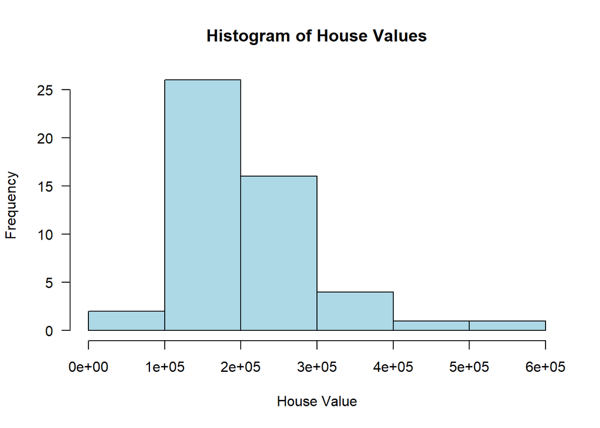

```r
# Create histogram with specified breaks
hist(myData$House_Value,
     breaks = seq(0, 600000, by = 100000),
     main = "Histogram of House Values",
     xlab = "House Value",
     ylab = "Frequency",
     col = "lightblue",
     border = "black",
     las = 1)
```